# **Exploring Potential Predictors of Postgraduate Financial Success**

# I. Introduction

Attending a college is a big investment both for the individual and his/her family: it involves the opportunity cost of working to be paid as well as the actual cost of attendance (i.e. tuition, etc.). Naturally, any person (or family) interested in college education considers various factors including academic prestige, location, and the cost of attendance. Though individuals may and do differ in these considered factors and their relative weights, one common influential factor for deciding which college to attend (or whether to attend a college at all) is the degree of postgraduate financial success. Simply put, many people seem to care the question: Will getting education here raise my future pay — if so, how much? The question can be rephrased as the following: What institution-level characteristics are significant indicators of postgraduate financial success? Here, I would like to probe this question using the College Scoreboard Data from the U.S. Department of Education.

### Data

The [College Scoreboard Data](https://collegescorecard.ed.gov/data/) is a rich set of data containing educational, administrative, and financial information of all degree-granting institutions in America over the past two decades. The original data are saved in CSV files, with each file containing data for each year. Each file is quite large (~100 MB) containing thousands of rows and columns, so accessing data in this form is not practical. Kaggle kindly pre-processed and converted the data into [more digestible formats](https://www.kaggle.com/kaggle/college-scorecard) including SQLite database.

For the current analysis, I have decided to use 2 smaller CSV files (`Most+Recent+Cohorts+(Scorecard+Elements).csv` and `Most+Recent+Cohorts+(Treasury+Elements).csv`) separately prepared by the U.S. Department of Education to include selective fields (i.e. variables) from the most recent year (2014-2015). I have merged these files, selected and renamed variables of interest, cleaned/pre-processed their values (see `scorecard_clean.Rmd` for more detailed processes).

The resulting data set (`scorecard_clean.csv`) contains 50 variables, whose information is documented in `scorecard_codebook.xlsx`.

# II. Analysis

First, let’s see the available variables and their values (`region` had been created based on `state`; other new variables will be created and used in a similar way).

```
##  [1] "id"                   "inst_name"            "city"                 "state"                "locale"
##  [6] "operation"            "control"              "degree"               "religious_affil"      "gender_affil"
## [11] "num_UGDS"             "UGDS_white"           "UGDS_black"           "UGDS_hispanic"        "UGDS_asian"
## [16] "UGDS_AIAN"            "UGDS_NHPI"            "UGDS_multi"           "UGDS_foreign"         "UGDS_NA"
## [21] "avg_age_entry"        "age_GT23_prop"        "female_prop"          "married_prop"         "dependent_prop"
## [26] "veteran_prop"         "first_gen_prop"       "SAT_CR_mid"           "SAT_MT_mid"           "retention_FT"
## [31] "retention_PT"         "fam_income_median"    "fam_income_mean"      "avg_net_cost"         "cost_income1"
## [36] "cost_income2"         "cost_income3"         "cost_income4"         "cost_income5"         "Pell_prop"
## [41] "Pell_ever_prop"       "fed_loan_prop"        "fed_loan_ever_prop"   "grad_debt_median"     "GT25K_P10_prop"
## [46] "earn_P10_median"      "earn_P10_mean"        "earn_P10_SD"          "earn_P10_mean_female" "earn_P10_mean_male"
## [51] "region"
```

```
## Observations: 7,804
## Variables: 51
## $ id                   (int) 100654, 100663, 100690, 100706, 100724, 100751, 100760, 100812, 100830, 100858, 100937...
## $ inst_name            (fctr) Alabama A & M University, University of Alabama at Birmingham, Amridge University, Un...
## $ city                 (fctr) Normal, Birmingham, Montgomery, Huntsville, Montgomery, Tuscaloosa, Alexander City, A...
## $ state                (fctr) AL, AL, AL, AL, AL, AL, AL, AL, AL, AL, AL, AL, AL, AL, AL, AL, AL, AL, AL, AL, AL, A...
## $ locale               (fctr) city, city, city, city, city, city, town, town, city, city, city, rural, town, city, ...
## $ operation            (fctr) operating, operating, operating, operating, operating, operating, operating, operatin...
## $ control              (fctr) public, public, private_nonprofit, public, public, public, public, public, public, pu...
## $ degree               (fctr) bachelor, bachelor, bachelor, bachelor, bachelor, bachelor, associate, bachelor, bach...
## $ religious_affil      (fctr) NA, NA, Protestant, NA, NA, NA, NA, NA, NA, NA, Protestant, NA, Protestant, NA, NA, N...
## $ gender_affil         (fctr) coed, coed, coed, coed, coed, coed, coed, coed, coed, coed, coed, coed, coed, coed, c...
## $ num_UGDS             (int) 4051, 11200, 322, 5525, 5354, 28692, 1779, 2999, 4322, 19761, 1181, 1769, 523, 599, 19...
## $ UGDS_white           (dbl) 0.0279, 0.5987, 0.2919, 0.7012, 0.0161, 0.7865, 0.6785, 0.7513, 0.5532, 0.8543, 0.8103...
## $ UGDS_black           (dbl) 0.9501, 0.2590, 0.4224, 0.1310, 0.9285, 0.1140, 0.2945, 0.1064, 0.3031, 0.0714, 0.0940...
```

[output cut: 38 more lines]

We see that there are two different measures of postgraduate financial success: `earn_P10_mean` and `earn_P10_median`. Let’s take a closer look at them to see which one will be a more appropriate measure to use for our analysis.

## 1. Measures of Postgraduate Financial Success

### Postgraduate Earnings: Mean vs. Median

```
##         earn_P10_mean earn_P10_median
## Min.            12300            8400
## 1st Qu.         27300           24200
## Median          34500           31200
## Mean            37180           33230
## 3rd Qu.         43300           39200
## Max.           250000          250000
## NA's             2168            2168
```

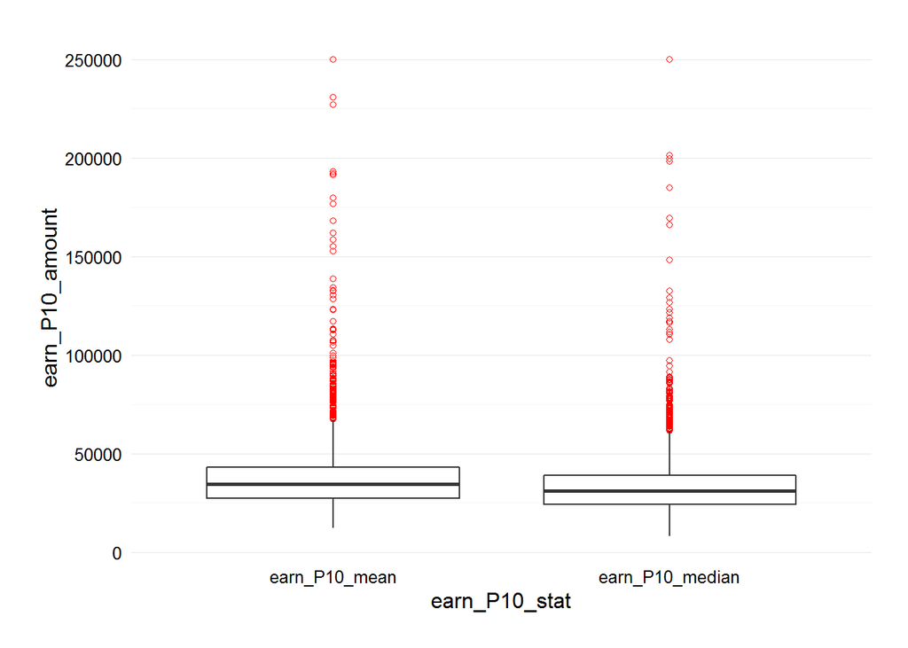

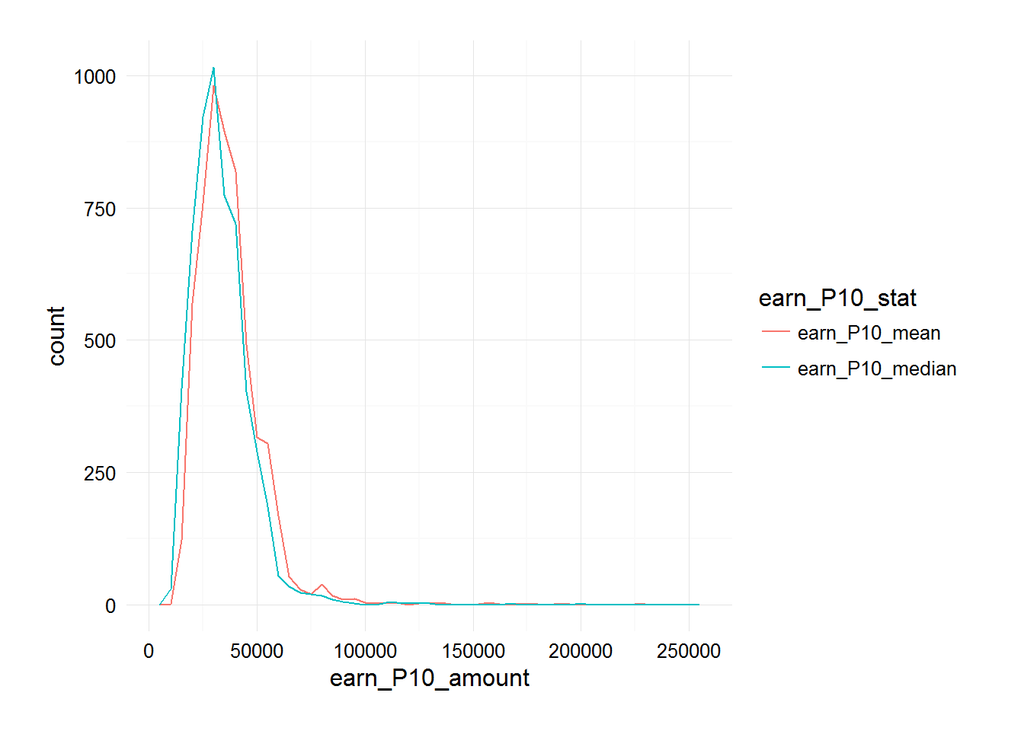

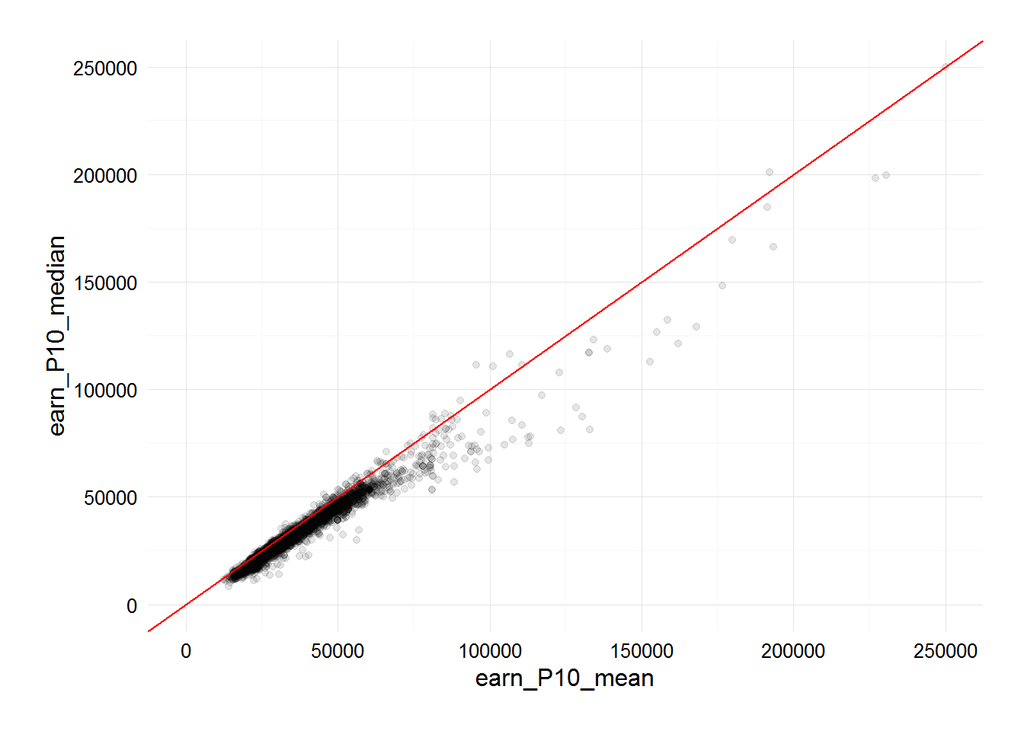

The plots show that the mean postgraduate earnings tend to be higher than the median postgraduate earnings. This is not much surprising since income distributions normally tend to be positively skewed, and the mean is necessarily greater than the median in any positively skewed distribution. However, it should be noted that the divergence in the current case is not large, and we can use the two statistics interchangeably as an indicator of postgraduate financial success. As the median is more reasonable measure of central tendency in a positively skewed distribution, I will employ the median postgraduate earnings for the subsequent analysis. However, there will be some cases where the use of the mean postgraduate earnings is unavoidable (that is, the mean is the only available statistic). In these cases, I will employ the mean instead of the median, and our exploration at this point ensures that such practice is not unreasonable.

Some words are in order regarding the distribution. Both the mean and the median postgraduate earnings display highly positively skewed distributions, indicating existence of a few “outperformers”. This is very similar to what we often observe in individual (or household) income distribution. The “divide” between the common and the extraordinary seems to lie around $60,000. For most institutions, the median postgraduate earnings are less than $40,000, with the “peak” (i.e. mode) being around $30,000.

Now, let’s turn our attention to some “outperformers” whose median postgraduate earnings are greater than $100,000 to see what is unique about them. This may help us to identify potential indicators of postgraduate financial success.

### Postgraduate Earnings: Outliers

```
## Source: local data frame [22 x 5]
##
##                                               inst_name earn_P10_median           control   degree    region
##                                                  (fctr)           (int)            (fctr)   (fctr)    (fctr)
## 1                          Medical College of Wisconsin          250000 private_nonprofit graduate   Midwest
## 2                                Albany Medical College          201200 private_nonprofit graduate Northeast
## 3               A T Still University of Health Sciences          199600 private_nonprofit graduate   Midwest
## 4          West Virginia School of Osteopathic Medicine          198300            public graduate     South
## 5  University of Massachusetts Medical School Worcester          184900            public graduate Northeast
## 6                              New York Medical College          169600 private_nonprofit graduate Northeast
## 7  Rosalind Franklin University of Medicine and Science          166200 private_nonprofit bachelor   Midwest
## 8          Philadelphia College of Osteopathic Medicine          148400 private_nonprofit graduate Northeast
## 9       University of North Texas Health Science Center          132400            public graduate     South
## 10                           Baylor College of Medicine          129000 private_nonprofit graduate     South
## 11                              Meharry Medical College          126700 private_nonprofit graduate     South
## 12                Western University of Health Sciences          123200 private_nonprofit graduate      West
## 13                        SUNY Downstate Medical Center          121500            public bachelor Northeast
## 14               University of California-San Francisco          118900            public graduate      West
## 15                  Midwestern University-Downers Grove          117000 private_nonprofit graduate   Midwest
## 16                       Midwestern University-Glendale          117000 private_nonprofit graduate      West
## 17                                     MCPHS University          116400 private_nonprofit bachelor Northeast
## 18                           Upstate Medical University          112900            public bachelor Northeast
## 19                         St Louis College of Pharmacy          111600 private_nonprofit graduate   Midwest
## 20                            Samuel Merritt University          111500 private_nonprofit bachelor      West
## 21       Albany College of Pharmacy and Health Sciences          110600 private_nonprofit bachelor Northeast
## 22     University of California-Hastings College of Law          107900            public graduate      West
```

Several things grab our attention:

- First, these “outperforming” institutions are mostly private nonprofit.
- They also tend to be graduate-level institutions — even institutions classified as primarily undergraduate (`bachelor`) here are renowned for their graduate programs.
- Though not as apparent as previous observations, many of these institutions are located in `Northeast`.
- Finally, institution names tell us that many of them are specialized in medicine.

In sum, these observations make us suspect that institutional control type, primary degree type, regional location, and specialization in medicine can be potential indicators of postgraduate financial success.

Let’s examine this conjecture based on all institutions in the data set.

## 2. Administrative Characteristics

### Control Type

We first examine the distribution of different control types.

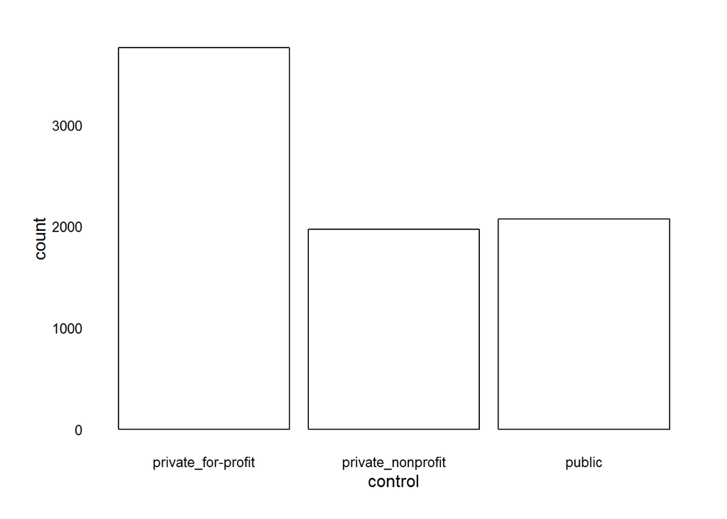

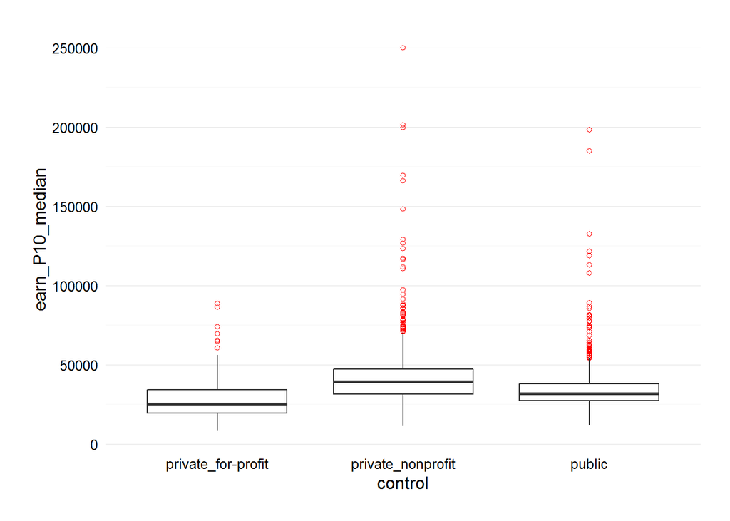

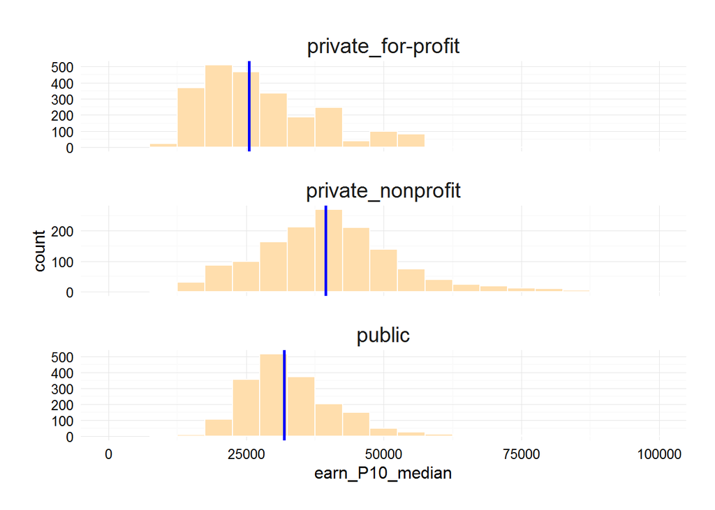

### Primary Degree Type

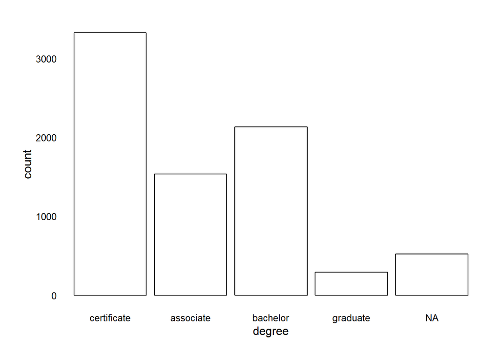

Certificate granting institutions form the greatest proportion, and there are relatively few graduate institutions. We disregard institutions whose primary degree type is unavailable (i.e. NA) for bivariate analysis below.

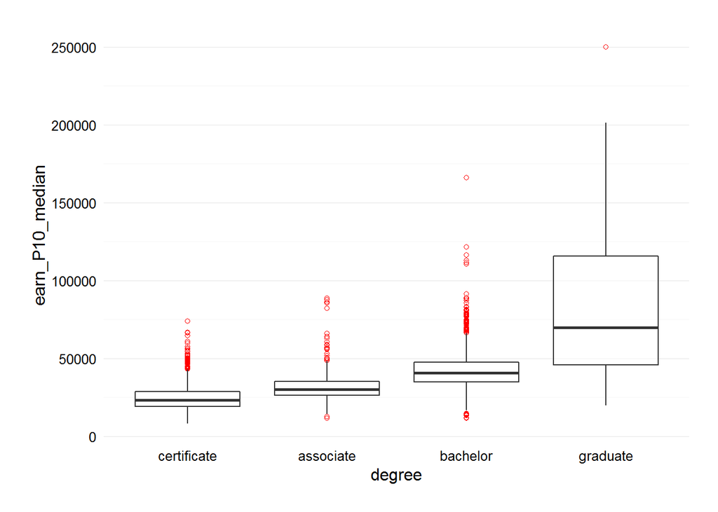

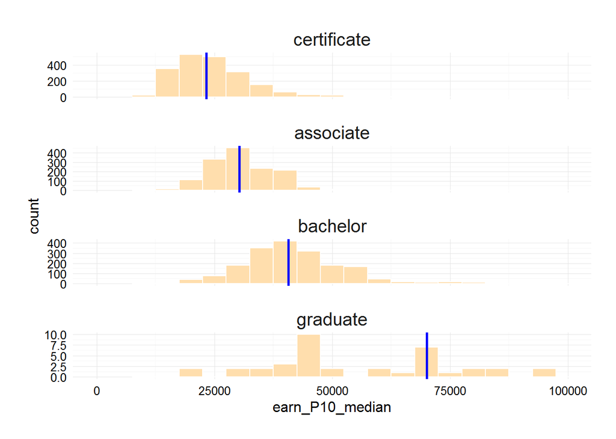

Clearly, institutions whose primary degree level is higher tend to have higher postgraduate earnings. However, we see a wider interquartile range for the `graduate` subgroup, which suggests that these institutions vary more in their levels of postgraduate financial success.

### Region

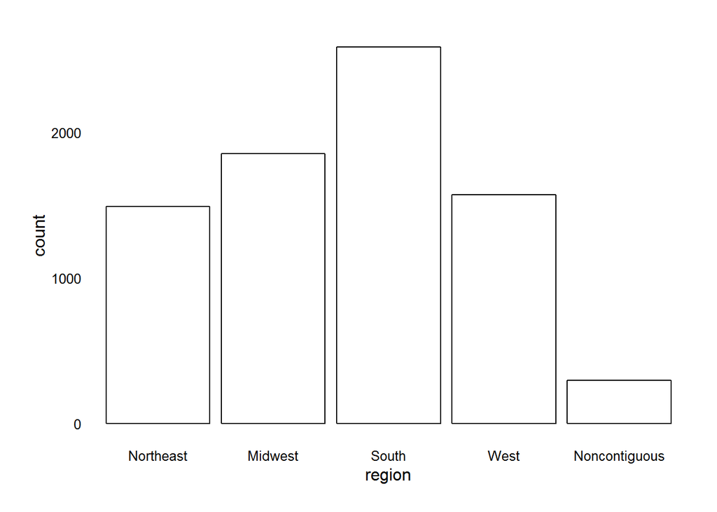

`South` has the greatest number of higher education institutions, which I personally find quite surprising. `Noncontiguous` region has the least number of higher education institutions, which should not be much surprising considering its small population.

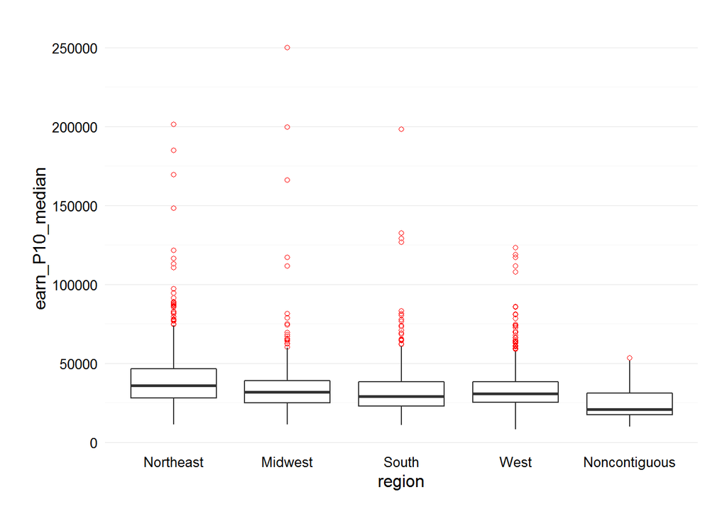

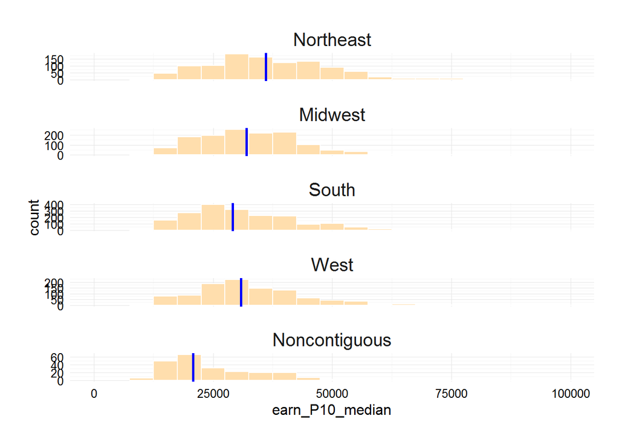

As expected, regional variation of postgraduate earnings is not as pronounced as variation by control or degree type. Even though it is possible to identify some pattern (that the median postgraduate earnings tend to be higher for institutions in `Northeast` region, followed by institutions in `Midwest`, `West`, `South`, and `Noncontiguous` regions in turn), its small extent suggests that it can be due to chance. In other words, the pattern we identify from this data may not exist in other data. Yet, institutions in `Noncontiguous` region tend to have noticeably lower postgraduate earnings than institutions in other regions, which may more closely reflect reality.

At this point, it is worth thinking about relationships among these three variables. Is it possible that the pattern we see in one variable is primarily due to its relation to another variable? For instance, is it possible that private nonprofit institutions tend to have higher postgraduate earnings *because* this educational sector has more higher-level (i.e. `graduate` and `bachelor`) institutions? This seems quite plausible since differing financial return for different educational levels is a well-known phenomenon and makes an intuitive sense. Variation by region and institutional control type, on the other hand, are not as intuitively appealing.

Let’s explore this possibility by examining distribution of degree types in `control` and `region`.

### Distribution of Degree Types by Region and Control Type

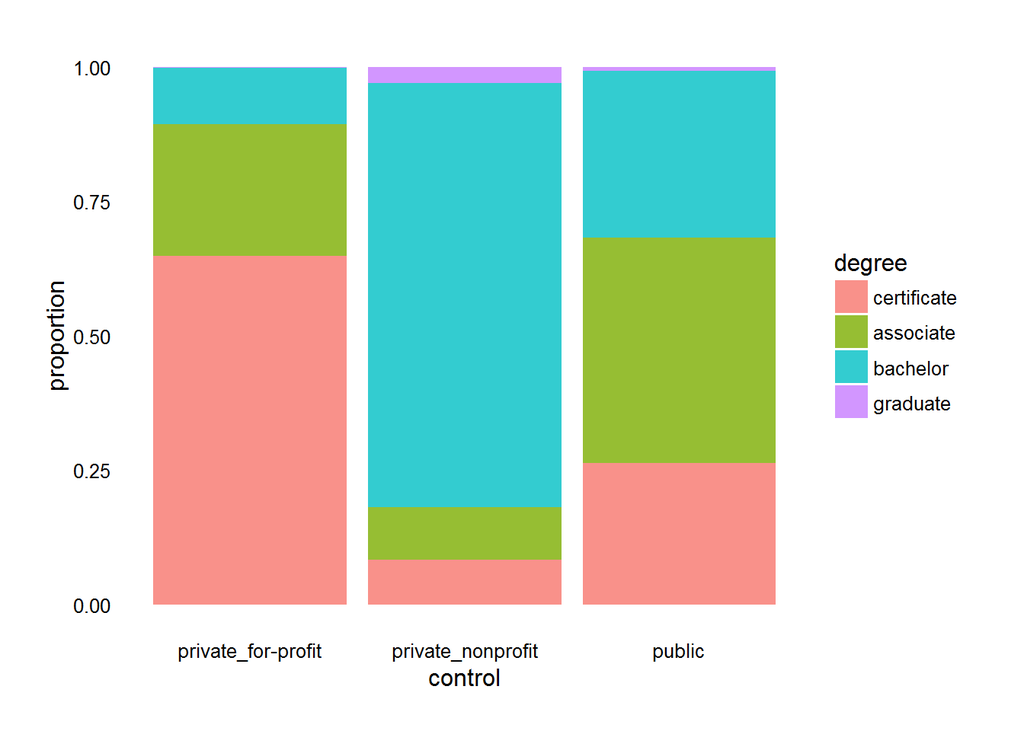

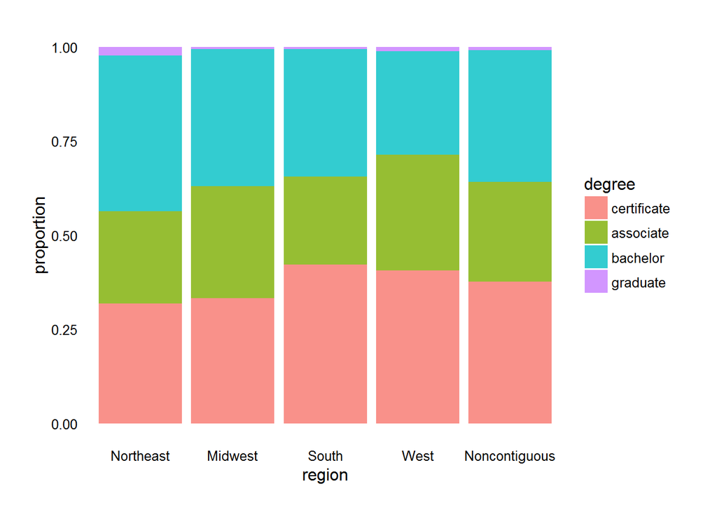

Our suspicion turns out to be valid for control type: Most institutions in the private nonprofit sector primarily grant high-level degrees (i.e. `graduate` and `bachelor`) while those in the private for-private sector are mostly low-level degree granting institutions (i.e. `certificate` and `associate`).

The similar pattern seems to exist in the regional distribution, where `Northeast` region has the greatest proportion of high-level degree granting institutions. However, this logic of degree level ratio does not hold quite well for the other regions. In particular, `Noncontiguous` region stands out as it shows a relatively greater proportion of high-level degree granting institutions (recall that institutions in this region tend to have noticeably lower postgraduate earnings).

These observations then suggest that primary degree type largely explains variation of postgraduate financial success across control types, but not so much across regions.

To further assess our conjecture, let’s now examine variations by region and control type while adjusting for primary degree type.

### Postgraduate Earnings by Control Type, Adjusting for Degree Type

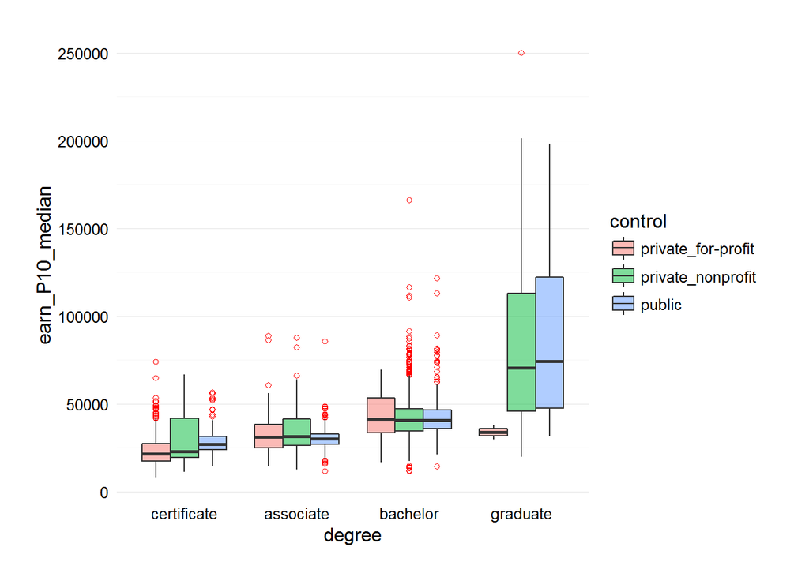

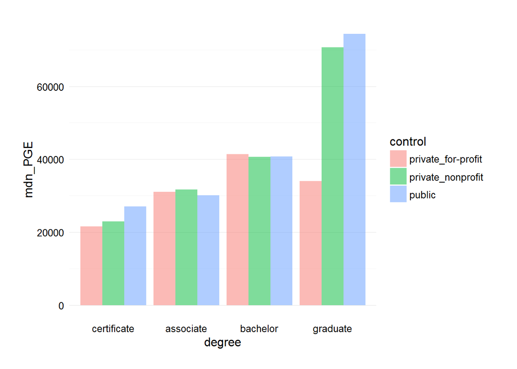

We see that the previously observed pattern (`private_nonprofit` > `pubic` > `private_for-profit`) largely disappears after adjusting for degree type.

### Postgraduate Earnings by Region, Adjusting for Degree Type

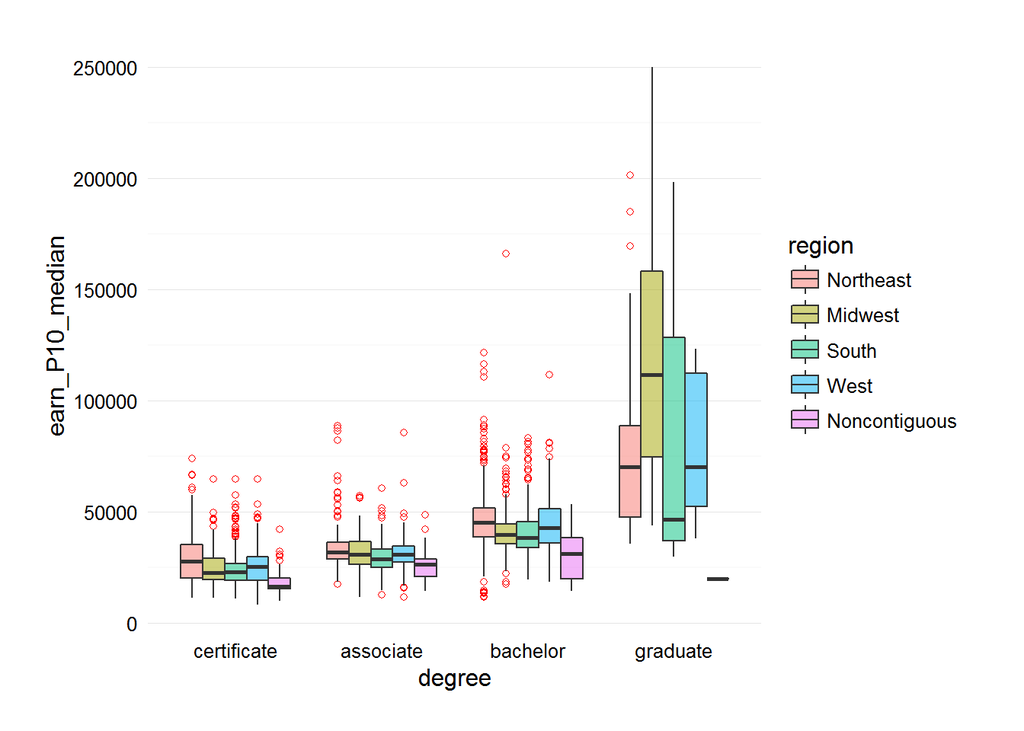

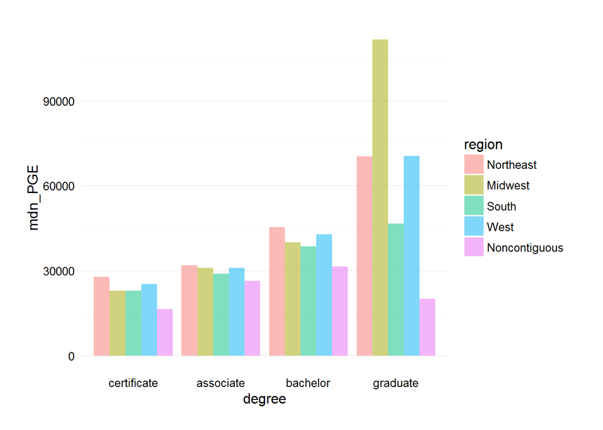

Again, we see that the previously observed regional pattern (`Northeast` > `Midwest` > `West` > `South` > `Noncontiguous`) breaks after adjusting for degree type. However, this does not smoothly translate into a confound effect as the formerly observed “pattern” is very weak and is hence dubious as to its validity. In other words, the reason why we see the breakdown of the formerly observed “pattern” is because this “pattern” itself was due to chance.

Yet, two things are noteworthy in this case. First, though the order is a bit different from the previously observed one, there still seems to exist some pattern at least across `certificate`, `associate`, and `bachelor` subgroups (see the bar plot which compares the regional median postgraduate earnings across primary degree types). Second, noticeably lower postgraduate earnings for institutions in `Noncontiguous` region persist even after adjusting for degree type. In light of these considerations, we should probably not disregard region as a completely irrelevant factor for postgraduate financial success.

Now, let’s reverse the “roles” and examine variations by primary degree type while adjusting for region and control type.

### Postgraduate Earnings by Degree Type, Adjusting for Control Type

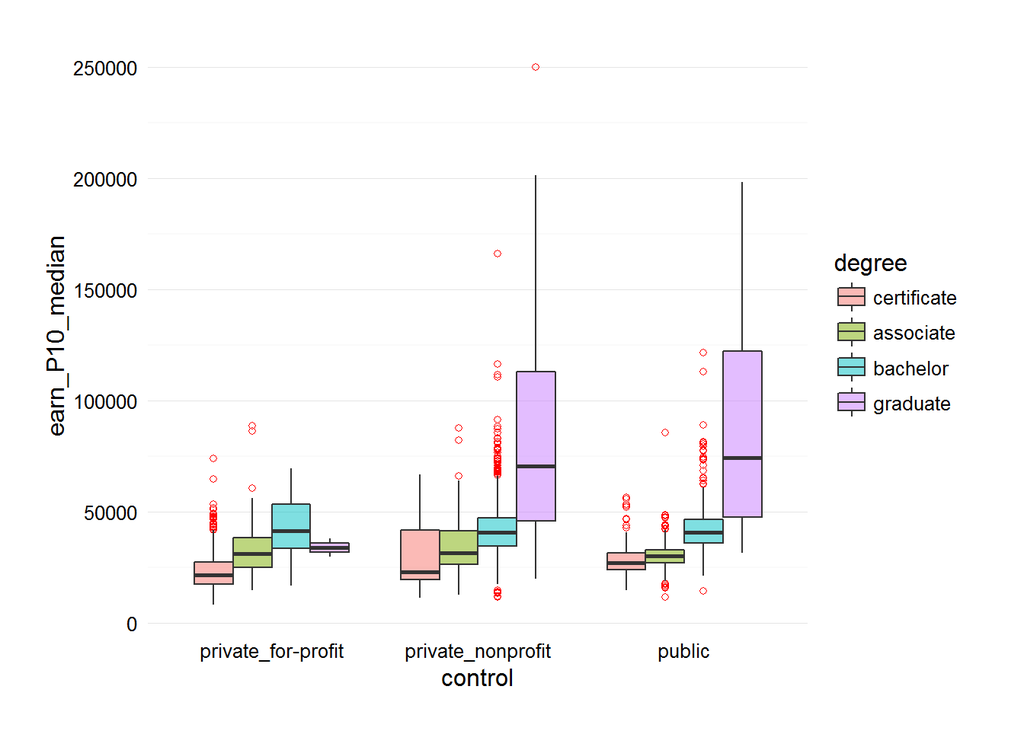

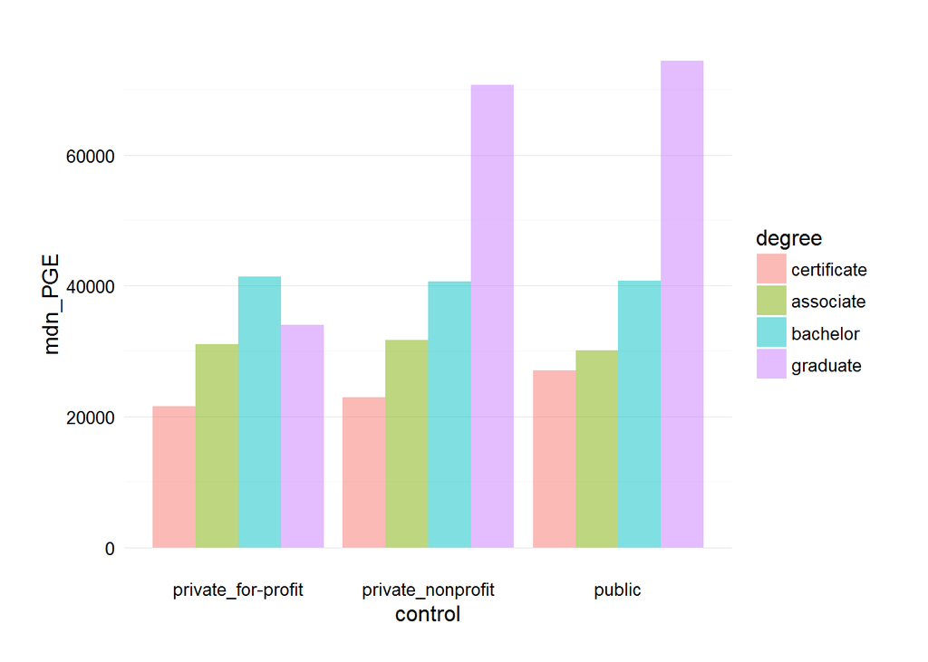

We see that the previously observed pattern (`graduate` > `bachelor` > `associate` > `certificate`) largely persists across different control types. An exception is found in `private_for-profit` sector, where postgraduate earnings of `graduate` institutions are considerably less. This can be seen as an effect of interaction between control and degree types.

### Postgraduate Earnings by Degree Type, Adjusting for Region

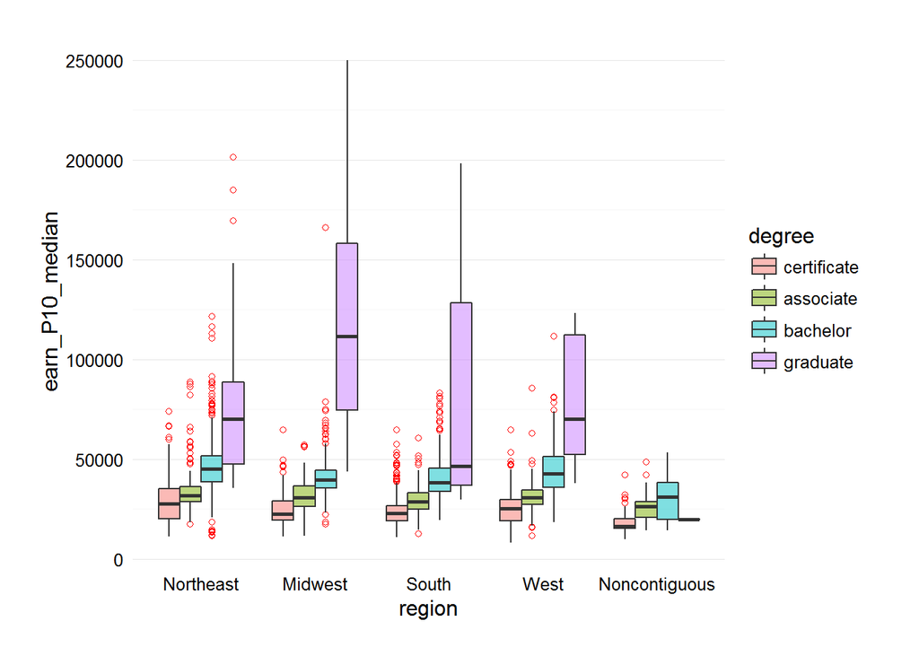

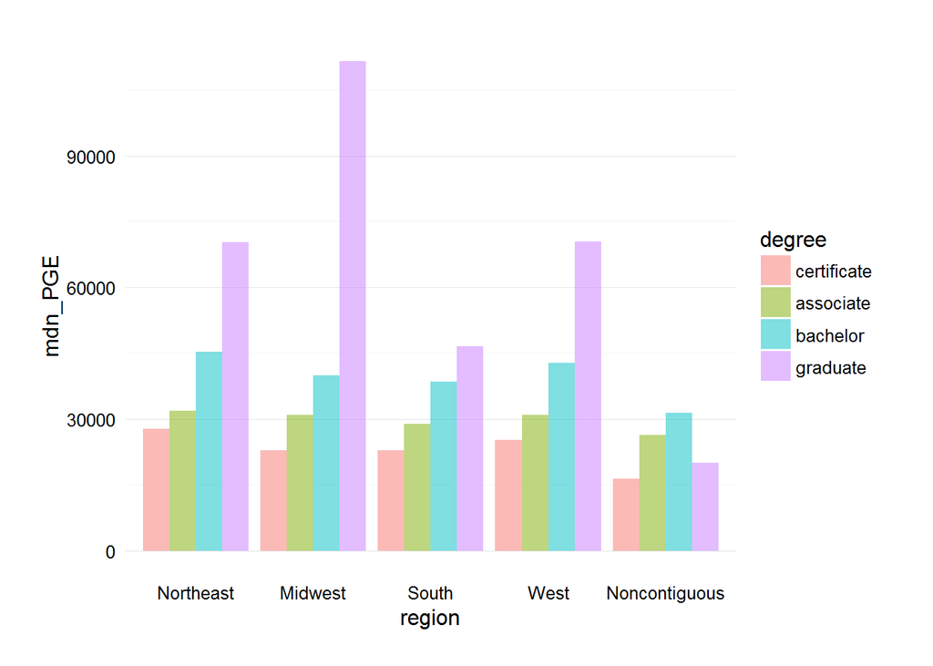

We get the parallel observations: the previously observed pattern (`graduate` > `bachelor` > `associate` > `certificate`) largely persists across different subgroups (regions), with an exception (`Noncontiguous`) where postgraduate earnings of `graduate` institutions are considerably less. Again, this “exception” can be seen as the effect of interaction between region and primary degree type. Relatively greater variation in postgraduate earnings of `graduate` institutions can be seen as another interaction effect.

To summarize, our investigation so far suggests that an institution’s primary degree type is an important indicator of its overall level of postgraduate financial success. We have also seen that this factor can explains a large portion of correlation between postgraduate financial success and other variables. In light of this, we will pay particular attention to primary degree type as a potential confound when examining other variables relevant to postgraduate financial success.

Now, let’s examine our suspicion that specialization in medicine may be associated with higher postgraduate earnings. Medical professions have been associated with much prestige, so this conjecture does not sound much surprising.

### Specialization in Medicine

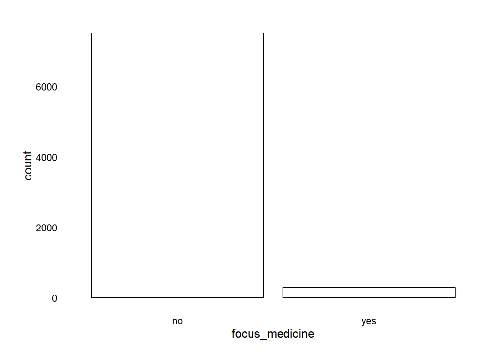

Quite expectedly, there are relatively few institutions that specialize in medicine. However, this is very likely to be an underestimation since we have identified medical institutions solely based on their names (e.g., “Medic”, “Pharm”, “Health”). For instance, the University of California, San Francisco (UCSF) has a primary focus in medical and health-related research even though its names does not indicate this.

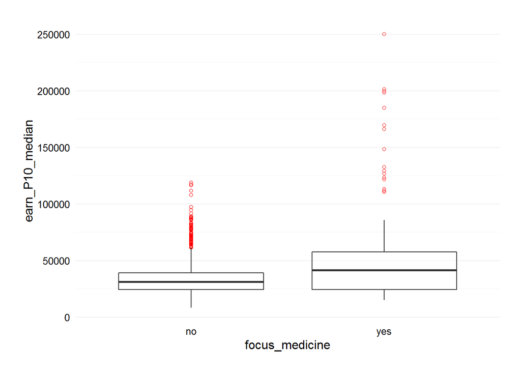

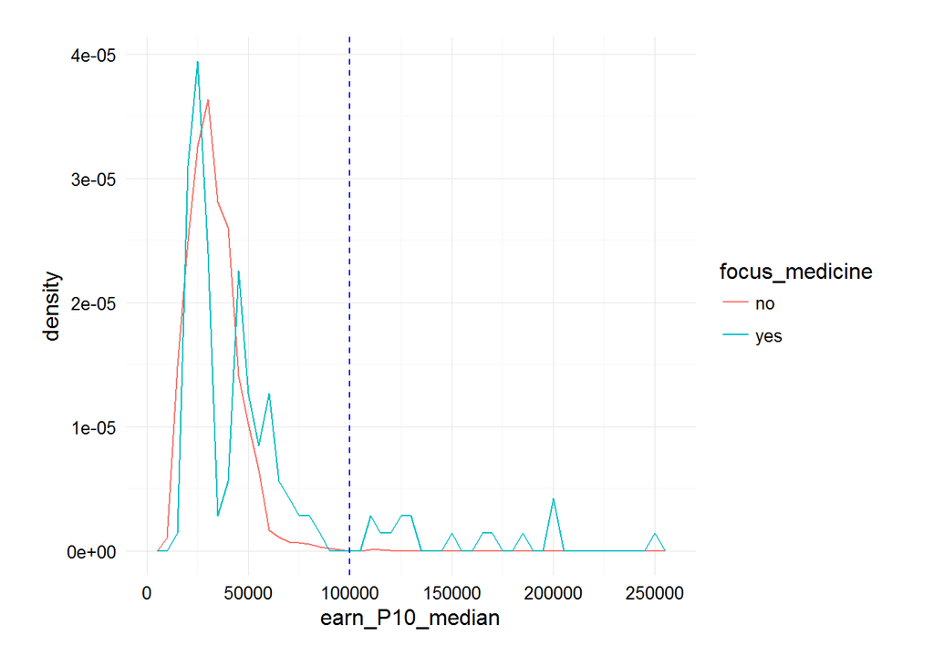

Quite surprisingly, institutions specializing in medicine do not seem as better off as we would expect: there are some positive outliers (which must be the “outperforming” institutions we had examined earlier), but the rest of the distribution is quite similar to that of non-medical institutions. Then, a question arises as to what divides the “outperforming” institutions and the others *within* medical institutions. Could degree type be an answer?

### Postgraduate Earnings by Specialization in Medicine, Adjusting for Degree Type

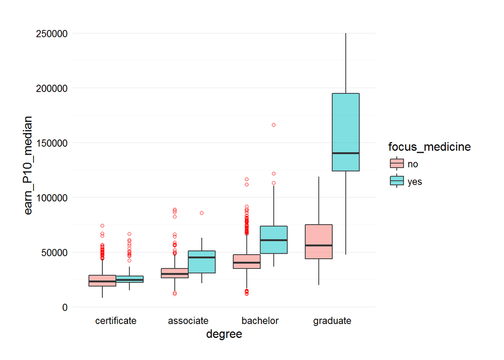

Indeed, degree type turns out to be the dividing factor: we see the discrepancy between medical and non-medical institutions increases as the primary degree level gets higher. This makes sense as the prestige associated with the medical profession mostly derives from medical “doctors” rather than from other medical staff (e.g., nurses). In sum, there seems to be an association between specialization in medicine and postgraduate financial success but this association is mediated by primary degree type.

## 3. Student Demographics

### Male vs. Female Postgraduate Earnings

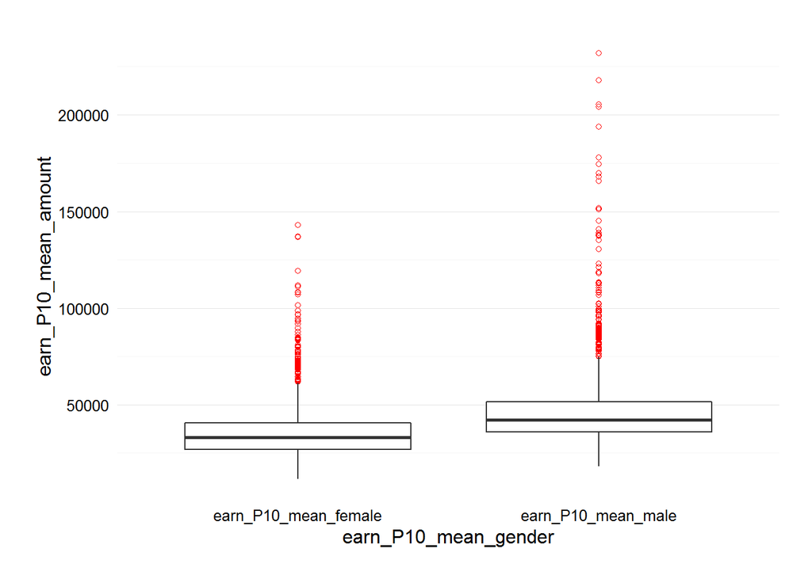

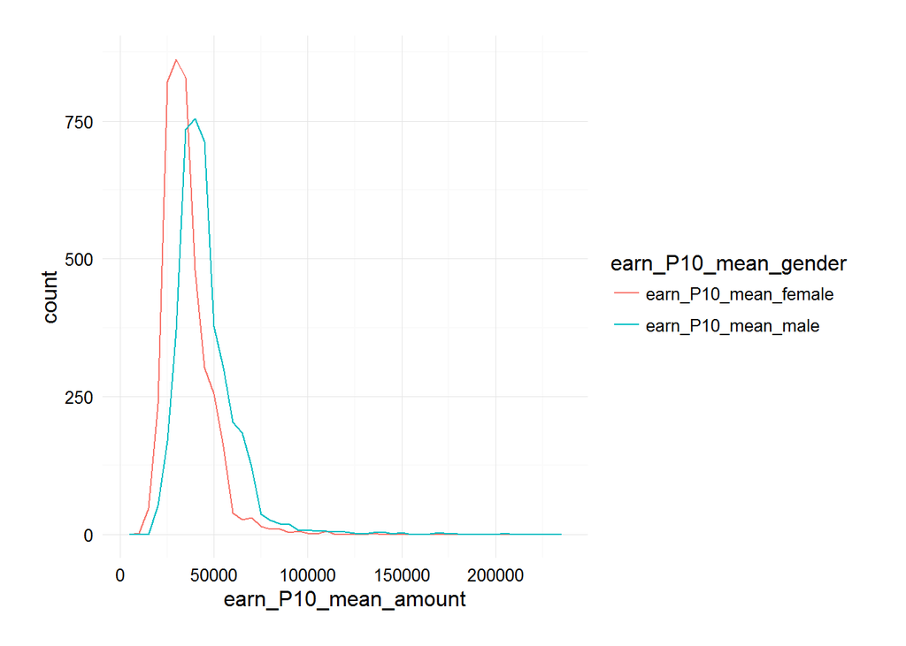

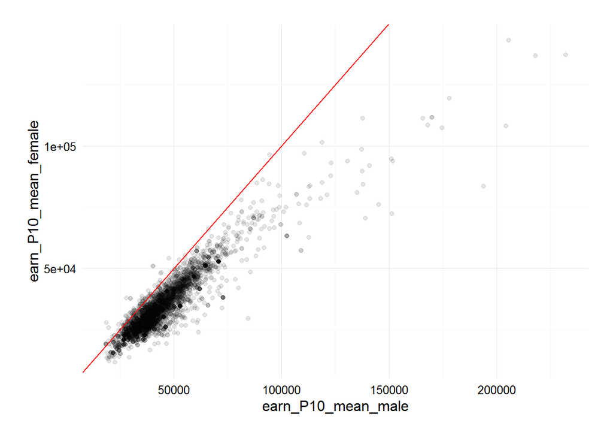

Note that the statistic used here is the *mean*, not the median, as the latter is not available gender-specifically. Our earlier discussion allows us to reply on the mean as a comparable measure of postgraduate financial success. The red line in the last plot is an identity line.

In most institutions, male postgraduate earnings are higher than female postgraduate earnings. Furthermore, the difference between male and female postgraduate earnings tend to be much bigger in institutions where male postgraduate earnings surpass female postgraduate earnings than in institutions where female postgraduate earnings surpass male postgraduate earnings.

We can further examine whether this gender difference in postgraduate earnings is statistically significant. Since we have information on the mean male vs. female postgraduate earnings for each institution (`earn_P10_mean_male` and `earn_P10_mean_female`, respectively), we can employ the paired t-test to see if their difference is statistically significant. Even though the distribution of institution-level gender difference in postgraduate earnings is highly skewed (see below), which violates the normality assumption of a t-test, our sample size (n > 4000) seems large enough to compensate for this violation and hence to allow us to conduct a t-test.

```
##  earn_P10_mean_male earn_P10_mean_female earn_P10_mean_genderDiff
##  Min.   : 18300     Min.   : 11800       Min.   :-10600
##  1st Qu.: 36100     1st Qu.: 27100       1st Qu.:  6300
##  Median : 42400     Median : 33200       Median :  9700
##  Mean   : 45501     Mean   : 35264       Mean   : 10237
##  3rd Qu.: 51600     3rd Qu.: 40800       3rd Qu.: 12900
##  Max.   :232000     Max.   :143100       Max.   :110400
```

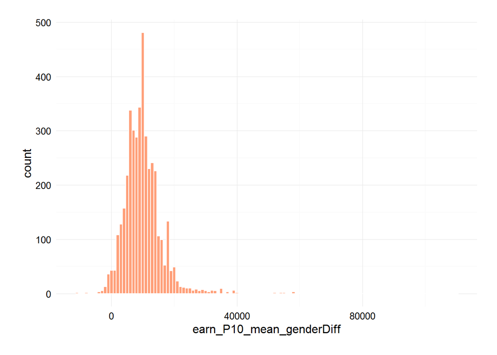

```
##
##  Paired t-test
##
## data:  scorecard$earn_P10_mean_male and scorecard$earn_P10_mean_female
## t = 93.356, df = 4140, p-value < 2.2e-16
## alternative hypothesis: true difference in means is not equal to 0
## 95 percent confidence interval:
##  10021.85 10451.81
## sample estimates:
## mean of the differences
##                10236.83
```

These observations strongly suggest that being a male is associated with higher postgraduate earnings. Which leads us to the following conjecture: Do institutions with more male students have higher postgraduate earnings?